# 3PG example

Juergen Knauer (adopted from Jinyan Yang)  
2023-08-13

Here we will go through changing each input files (met,species,thinning and parameters).

### 1) Met data

Our site is in Richmond NSW, dominated by E.tereticornis Sm. The site has a mean annual temperature of 17 $^\circ C$ and a mean annual precipitation of 800mm.

Let’s now read and look at the met data.

```r
met.df <- read.csv("/Users/30044953/Downloads/ros.met.csv")

head(met.df)
```

```
  X year month  tmp_ave   tmp_min  tmp_max     srad      prcp
1 1 2019     1 26.14389 20.693226 34.11613 9.653024 120.58065
2 2 2019     2 23.12694 17.093571 30.37179 9.154149  35.57143
3 3 2019     3 21.87528 16.526452 28.65613 6.836939 135.09677
4 4 2019     4 18.25206 11.964567 25.80133 6.119361   8.20000
5 5 2019     5 14.17635  7.054161 22.41516 4.759043  12.58065
6 6 2019     6 11.63213  5.483100 18.46767 3.516134  41.40000
```

```r
met.date <- apply(met.df[,c(2,3)],1,function(x) (paste(x,collapse = "-")))
met.date <- paste0(met.date,"-15")   # append pseudo day
met.df[,"date"] <- as.Date(met.date) # append to met.df data.frame
```

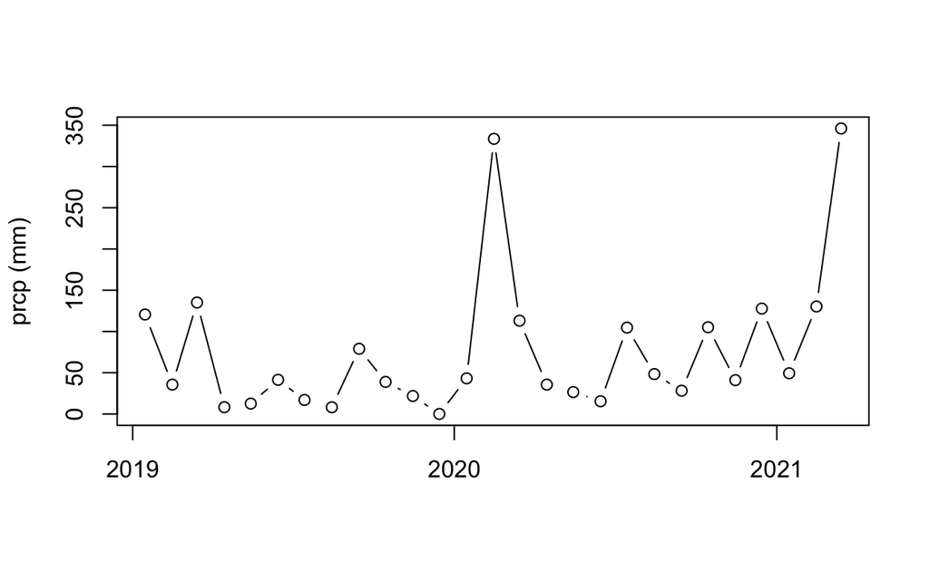

```r
plot(met.df$prcp ~ met.df$date,xlab='',ylab = 'prcp (mm)',type="b")
```

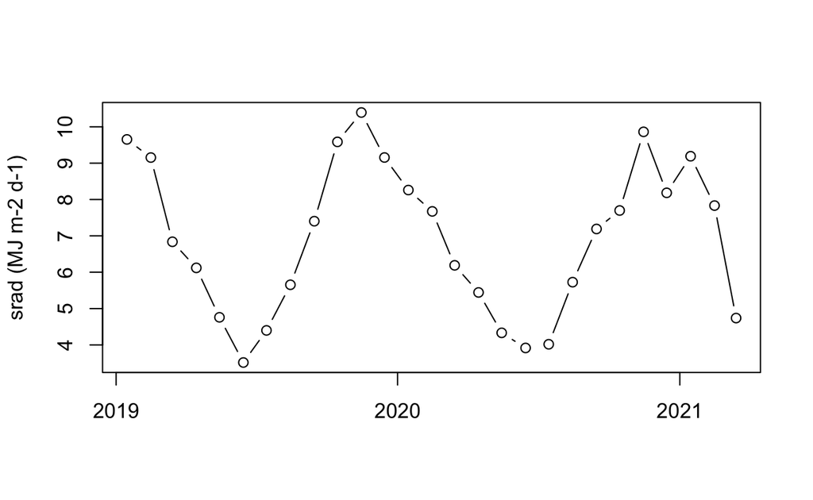

```r
plot(met.df$srad ~ met.df$date,xlab='',ylab = 'srad (MJ m-2 d-1)',type="b")
```

We need to put in number of frost days and $CO_{2}$ data.

```r
#
met.df$frost_days <- 0
#
met.df$co2  <- 410
met.df$srad <- 2.3 * met.df$srad  # photosynthetically active radiation to total radiation
```

### 2 Site information

```r
site.new <- d_site

site.new$latitude   <- -38
site.new$altitude   <- 50
site.new$soil_class <- 3
site.new$asw_min    <- 0
site.new$asw_max    <- 50
site.new$asw_i      <- 150
site.new$from       <- '2019-01'
site.new$to         <- '2021-03'
```

### 3 Species composition

Since we are using only one species, the inputs are just the initial conditions of the species.

```r
spc.new <- d_species[1,]
spc.new$species <- 'Eucalyptus tereticornis'
spc.new$planted <- '1920-01'
spc.new$fertility <- 1
spc.new$stems_n   <- 400
spc.new$biom_stem <- 90
spc.new$biom_root <- 10
spc.new$biom_foliage <- 0.2
```

### 4 Plant physiology

Let see if our species has been reported by previous literature.

```r
list.spc <- get_parameters(mode = "overview", sp_names = NULL)

euc.list <- list.spc$species[grep(pattern = 'Eucalyptus',x = list.spc$species)]

print(euc.list)
```

```
 [1] "Eucalyptus globulus"
 [2] "Eucalyptus grandis"
 [3] "Eucalyptus grandis"
 [4] "Eucalyptus grandis"
 [5] "Eucalyptus grandis"
 [6] "Eucalyptus grandis x urophylla"
 [7] "Eucalyptus grandis x urophylla"
 [8] "Eucalyptus grandis x urophylla"
 [9] "Eucalyptus grandis x urophylla"
[10] "Eucalyptus grandis x urophylla"
[11] "Eucalyptus urophylla"
[12] "Eucalyptus grandis x camaldulensis"
[13] "Eucalyptus globulus"
[14] "Eucalyptus nitens"
[15] "Eucalyptus saligna"
[16] "Eucalyptus pelita"
[17] "Eucalyptus cladocalyx"
[18] "Eucalyptus globulus"
[19] "Eucalyptus nitens"
[20] "Eucalyptus nitens"
[21] "Eucalyptus globulus"
[22] "Eucalyptus saligna"
[23] "Eucalyptus grandis x urophylla"
[24] "Eucalyptus grandis x urophylla"
[25] "Eucalyptus grandis"
```

We did not find our species but a similar one, E.globulus. We are going to use the most of the parameters from E.globulus as example.

```r
## overview of available parameters
get_parameters(mode = "overview", sp_names = 'Eucalyptus globulus')
```

```
   parset_id             species  age type year
2          2 Eucalyptus globulus even mono 2016
23        23 Eucalyptus globulus even mono 2006
89        89 Eucalyptus globulus even mono 2007
97        97 Eucalyptus globulus even mono 2002
                            region           country
2             Australia and Brazil Australia, Brazil
23                            <NA>          Portugal
89                            <NA>         Australia
97 Tasmania and Western Australia.         Australia
                     source
2    Almeida and Sands 2016
23       Fontes et al. 2006
89         Paul et al. 2007
97 Sands and Landsberg 2002
```

```r
## let's select the data from Australia
params.et <- get_parameters(mode = "parameters", sp_names = 'Eucalyptus globulus 97')

# We use Fagus sylvatica as template
par.new <- d_parameters[,c("parameter","Fagus sylvatica")]
colnames(par.new)[2] <- "Eucalyptus tereticornis"

## We change a few parameters manually
par.new[par.new$parameter == "Tmin",2] <- params.et[params.et$parameter == "Tmin",2]
par.new[par.new$parameter == "Tmax",2] <- params.et[params.et$parameter == "Tmax",2]
par.new[par.new$parameter == "Topt",2] <- params.et[params.et$parameter == "Topt",2]

par.new[par.new$parameter == 'alphaCx',2] <- params.et[params.et$parameter == 'alphaCx',2]
par.new[par.new$parameter == 'SLA0',2] <- 30
par.new[par.new$parameter == 'SLA1',2] <- 30

par.new[par.new$parameter == 'LAImaxIntcptn',2] <- 3
par.new[par.new$parameter == 'CoeffCond',2] <- 0.05

par.new[par.new$parameter == 'MaxAge',2] <- 500
par.new[par.new$parameter == 'fCalpha700',2] <- 1.8
par.new[par.new$parameter == 'fCg700',2] <- 0.6
```

### 4 Allometry and Thinning

```r
#
thin.new <- d_thinning[1,]

thin.new$species <- 'Eucalyptus tereticornis'

thin.new$age <- 200
#
size.new <- (d_sizeDist[,1:2])
names(size.new)[2] <- 'Eucalyptus tereticornis'
```

```r
# We follow the workflow from above, but with 'sizeDist' instead of 'parameters'
size.et <- get_parameters(mode = "sizeDist", sp_names = 'Eucalyptus globulus 97')

head(size.et)
```

```
  parameter Eucalyptus globulus 97
1   Dscale0                      0
2   DscaleB                      0
3  Dscalerh                      0
4   Dscalet                      0
5   DscaleC                      0
6   Dshape0                      0
```

```r
# It turns out there is no allometry information for Eucalyptus globulus!
# In this case, we assume the same allometry as for 'Fagus sylvatica'

size.new <- d_sizeDist[,c(1,2)]
colnames(size.new)[2] <- "Eucalyptus tereticornis"

head(size.new)
```

```
  parameter Eucalyptus tereticornis
1   Dscale0               0.1943880
2   DscaleB               1.2246192
3  Dscalerh               0.0000000
4   Dscalet               0.1277694
5   DscaleC               0.0000000
6   Dshape0               0.7881010
```

There are other parameter files related to thinning (d_thinning).

Now that we have all the input files, we can run the model!

### 5 Normal run

```r
climate.new <- prepare_climate(met.df,from="2019-01",to="2021-03")
out.et <- run_3PG(site = site.new,
                  species = spc.new,
                  climate = climate.new,
                  thinning = thin.new,
                  parameters = par.new,
                  size_dist = size.new,
                  settings = list(light_model = 2,
                                  transp_model = 2, phys_model = 2,
                                  correct_bias = 0, calculate_d13c = 0),
                  check_input = TRUE,
                  df_out = TRUE)


# What would have happened with more precipitation?
climate.new$prcp <- climate.new$prcp + 50
out.et.wet <- run_3PG(site = site.new,
                      species = spc.new,
                      climate = climate.new,
                      thinning = NULL,
                      parameters = par.new,
                      size_dist = size.new,
                      settings = list(light_model = 2,
                                    transp_model = 2, phys_model = 2,
                                    correct_bias = 0, calculate_d13c = 0),
                      check_input = TRUE,
                      df_out = TRUE)
```

Let’s check the change in GPP.

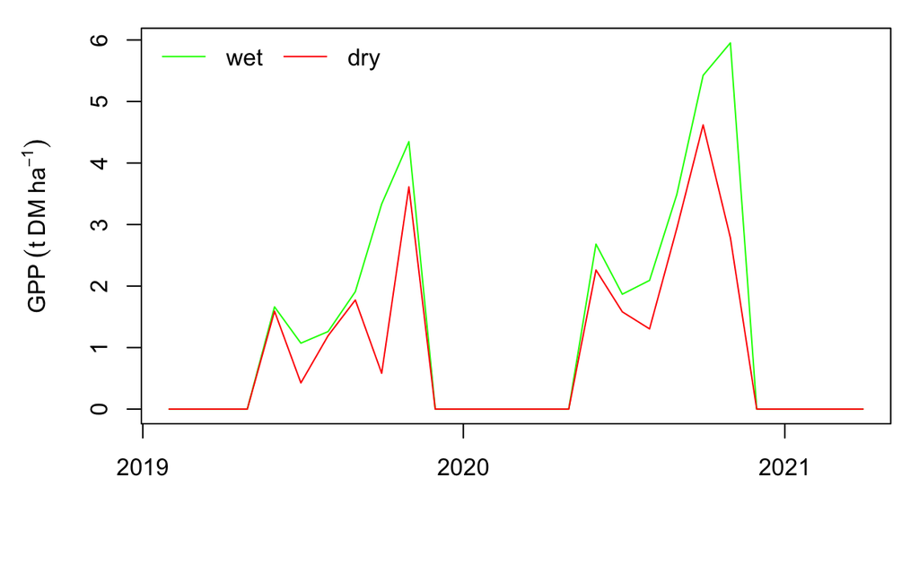

```r
par(mar=c(5,5,1,1))
plot(value~date,data = out.et.wet[out.et.wet$species == 'Eucalyptus tereticornis' &
                                  out.et.wet$variable == 'gpp',],
       type='l',xlab='',ylab=expression('GPP'~(t~DM~ha^-1)),col="green")

  points(value~date,data = out.et[out.et$species == 'Eucalyptus tereticornis' &
                                  out.et$variable == 'gpp',],
         type='l',xlab='',col="red")

  legend('topleft',legend = c('wet','dry'),
         lty='solid',col=c("green","red"),bty='n',horiz = T)
```

The effects of precipitation on GPP look reasonable.

But the GPP patterns look suspiciuous. Would we really expect GPP=0 throughout the summer and autumn?

How would we find out?